# Exploratory Data Analysis of Text Corpus

Ivan Lysiuchenko

September 14, 2018

## Introductions

In this milestone report we present an overview and exploratory analysis of the text corpus we use to build our predictive model. We briefly describe the loading and preprocessing step in Section 1. In Section 2 we explore the distribution of 1-, 2-, 3- and 4-grams in the overall corpus. Section 3 is an overview of the three files used to build the corpus (they represent extracts from blogs, news and tweets in English). Then we draw some conclusions on the observed distributions and outline further steps in building the predictive model.

This report is totally reproducible. You can find all the code in [this repository](https://github.com/ivanlis/yellow_dog_predictor). To work with corpora and n-grams, we use the quanteda R package.

## 1 Loading and feature extraction

An important problem arising when trying to load the corpora is the limited size of the main memory. We’ve been performing the loading task on a PC with 8 GB RAM (actually less available to R). As it is impossible to load all the three files into the memory and perform operations on them, we divide each one into chunks. Our splitFiles() function is in charge of doing that.

Then we execute extractFeatures(). When it is finished, we have the document-feature matrices (DFMs) of n-grams stored on the disk. They will be the base for our further research.

Pre-processing is done in several steps:

- Load a chunk file, create a quanteda corpus. Reshape it by sentence.
- Tokenize the corpus into unigrams, only removing punctuation. Let’s call these tokens “raw”.
- For each n = 1..4 build n-gram tokens out of the raw tokens.
- Filter these tokens: remove profane words, remove tokens containing non-alphabetic characters (except for the apostrophe and hyphen)
- Build a document-feature matrix (DFM) for the current corpus and current n.
- Merge the DFMs for all the chunks. This way we have 4 DFMs, one for each n-gram type.

We process all the unigrams and bigrams. For 3- and 4-grams we keep nearly 60% of the most frequent features due to memory restrictions.

## 2 Distribution analysis of the overall corpus

In this section we’ll explore how the frequencies of the features (1-, 2-, 3- and 4-grams) are distributed. We use our loadFrequencies() function which reads a DFM from a file and converts it into a vector of frequency values sorted in descendant order.

### Words

Let’s take a look at words first.

Our preprocessing step left 722333 different words. All of them account for 9.918394510^{7} entries. The most frequent words are the following:

```
##     the      to     and       a      of       i      in     for      is
## 4765950 2754529 2414931 2382339 2005507 1653914 1646168 1099450 1075203
##    that     you      it      on    with     was      my      at      be
## 1041899  942074  917586  818189  714646  624566  604573  571014  548300
##    this    have
##  544984  530601
```

Examples of unfrequent words:

```
##     oooohhhhhh     banana-how    updyke-type stakes-winning     bailjumper
##              1              1              1              1              1
```

It turns out that to cover 90% of all word usages we need to keep 7570 of the most frequent words. 50% is covered by 138 of them. The most frequent word is the with relative frequency of 0.0480516.

### Bigrams

The number of different bigrams is 13124767, the overall number of their entries is 9.104010110^{7}. 90% and 50% of the entries correspond to 4.02075710^{6} and 3.466510^{4} most frequent bigrams respectively. The most frequent bigram is of_the, its relative frequency is 0.004722. Other frequent bigrams are the following:

```
##   of_the   in_the   to_the  for_the   on_the    to_be   at_the  and_the
##   429895   407258   212966   200790   196143   161986   142363   125694
##     in_a with_the     is_a   it_was    for_a from_the   i_have    i_was
##   119043   105867   100812    96359    93748    87081    86461    86074
##    it_is    and_i   with_a  will_be
##    82235    82178    81862    81144
```

Examples of unfrequent bigrams:

```
##       drilled_again remember_battleship     battleship_ever
##                   1                   1                   1
##          nice_opens     check_hopefully
##                   1                   1
```

### Trigrams

```
##         one_of_the           a_lot_of     thanks_for_the
##              71257              62458              56209
##            to_be_a        going_to_be          i_want_to
##              38474              37560              32676
##         the_end_of         out_of_the           it_was_a
##              30892              30597              29754
##         as_well_as        some_of_the         be_able_to
##              28089              27872              27121
##           i_have_a looking_forward_to        part_of_the
##              25772              25652              25332
##          i_have_to       i_don't_know      thank_you_for
##              24366              23737              23619
##        the_rest_of         i_love_you
##              23457              22166
```

Among our fitered trigrams, these are the less frequent:

```
##    jordan_and_is      i_am_writin      am_writin_a    writin_a_song
##                1                1                1                1
## to_act_exhausted
##                1
```

### Four-grams

At the preprocessing step we filtered out the less frequent 4-grams. Now we keep 30684803 of different features. These features account for 4.580180110^{7} entries. The relative frequency of the most seen 4-gram is 1.673296610^{-4}. The most frequent 4-grams are the following:

```
##        the_end_of_the       the_rest_of_the         at_the_end_of
##                  7664                  6702                  6650
## thanks_for_the_follow    for_the_first_time      at_the_same_time
##                  6303                  6171                  5123
##        is_going_to_be       one_of_the_most         is_one_of_the
##                  4394                  4212                  4171
##      when_it_comes_to      in_the_middle_of         going_to_be_a
##                  4050                  3888                  3651
##         to_be_able_to        if_you_want_to     thanks_for_the_rt
##                  3628                  3353                  3348
##       i_don't_want_to     thank_you_for_the     can't_wait_to_see
##                  3241                  3184                  3144
##       one_of_the_best     thank_you_so_much
##                  2974                  2698
```

These are the less frequent among our fitered 4-grams:

```
## kill_your_relationship_at    your_relationship_at_a
##                         1                         1
##  infused_rye_whiskey_last  relationship_at_a_public
##                         1                         1
##    rye_whiskey_last_night
##                         1
```

### Empirical frequency distributions

Let’s show the frequencies of the words, bigrams, trigrams and 4-grams on the same graph, using a logarithmic (log-log) scale.

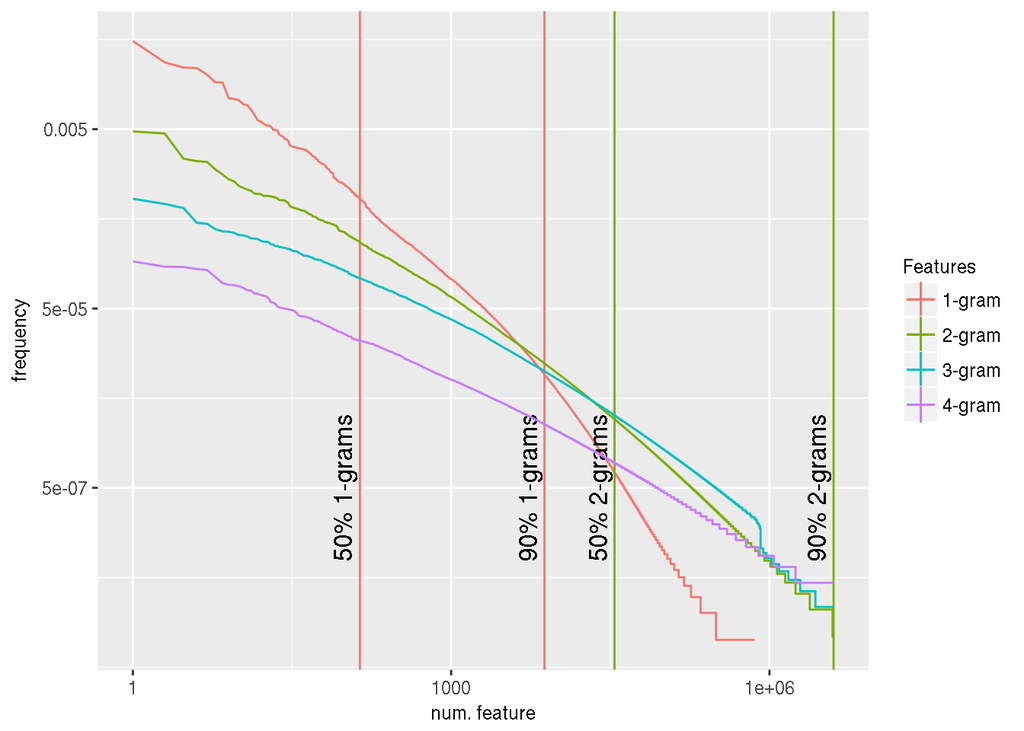

It may be interesting to take a look at the random variable whose values are all possible values of relative frequency (from 0 to 1). We estimate the probability of a relative frequency value as the number of the features occurring with this relative frequency divided by the overall number of features.

Here is the summary related to unigrams:

```
##      Min.   1st Qu.    Median      Mean   3rd Qu.      Max.
## 1.000e-08 1.000e-08 1.000e-08 1.380e-06 4.000e-08 4.805e-02
```

The mean of the relative frequency for unigrams is 1.38440310^{-6}, whereas its standard deviation is 9.611628910^{-5}.

Here is the summary related to bigrams:

```
##      Min.   1st Qu.    Median      Mean   3rd Qu.      Max.
## 1.100e-08 1.100e-08 1.100e-08 7.600e-08 2.200e-08 4.722e-03
```

The mean of the relative frequency for bigrams is 7.619182910^{-8}, whereas its standard deviation is 3.082047410^{-6}. We can see that the mean for unigrams is higher, and the standard deviation is bigger as well. It means that on average there are more important high frequency features than in the case of bigrams. Also there is more dispersion of frequency values for unigrams in comparison with bigrams. The majority of words have low frequency, although there is a set of very high-frequency words. 2-grams show a similar pattern, but tend to have lower on average, less dispersed frequencies.

In the following box plot it can be seen how the relative frequency distributions are different between unigrams and bigrams:

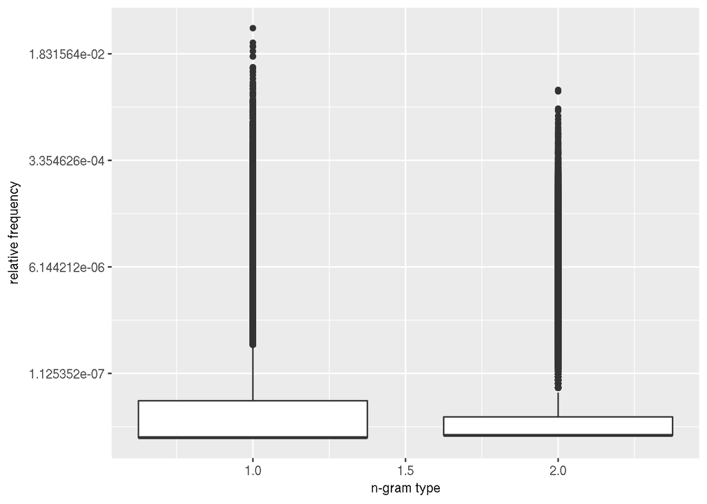

Both distributions are right skewed (towards higher frequencies). This efect is stronger in the case of unigrams: the right tail is ‘heavier’.

## Files overview

### Lines count and length

To see what the lines of every file look like we use a simple function called computeLineStats(). The minimum, maximum, average line length as well as line counts are as follows:

```
##         minLength maxLength avgLength lineNum
## Blogs           1     40833 229.98695  899288
## News            1     11384 201.16285 1010242
## Twitter         2       140  68.68045 2360148
```

We can see that the line length average is similar in the blogs and news texts included in the corpora. On the opposite, no line belonging to the tweets exceeds 140 characters.

### Vocabulary and n-grams

Let’s explore n-gram tokens for the three files our corpus consists of. We analyze the tokens computed after dividing the correspondent corpus into sentences. Tokens containing punctuation, numbers and profane words are deleted.

### Blogs

The numbers of types (unique features) and tokens (their entries) for the blog corpus is the following:

```
##    nGram   nTypes  nTokens
## 1      1   346863 36733088
## 4      2  5828524 34286120
## 7      3 16757808 31958239
## 10     4 24251739 29726232
```

The most frequent n-grams for this corpus:

```
##       1       2           3                  4
## 1   the  of_the  one_of_the     the_end_of_the
## 2   and  in_the    a_lot_of    the_rest_of_the
## 3    to  to_the  as_well_as      at_the_end_of
## 4     a  on_the    it_was_a   at_the_same_time
## 5    of   to_be     to_be_a   when_it_comes_to
## 6     i and_the some_of_the      to_be_able_to
## 7    in for_the  the_end_of    one_of_the_most
## 8  that   i_was  out_of_the for_the_first_time
## 9    is   and_i  be_able_to   in_the_middle_of
## 10   it  i_have a_couple_of      is_one_of_the
```

### News

Types and tokens for the news corpus:

```
##    nGram   nTypes  nTokens
## 2      1   302268 33258885
## 5      2  5778468 30695752
## 8      3 15787020 28310809
## 11     4 21556310 26076748
```

The most frequent n-grams:

```
##       1        2                3                    4
## 11  the   of_the       one_of_the       the_end_of_the
## 12   to   in_the         a_lot_of   for_the_first_time
## 13  and   to_the       as_well_as        at_the_end_of
## 14    a   on_the      part_of_the      the_rest_of_the
## 15   of  for_the       the_end_of  said_in_a_statement
## 16   in   at_the according_to_the in_the_united_states
## 17  for  and_the       out_of_the      one_of_the_most
## 18 that     in_a      some_of_the     at_the_same_time
## 19   is    to_be          to_be_a        is_one_of_the
## 20   on with_the     in_the_first at_the_university_of
```

### Tweets

```
##    nGram   nTypes  nTokens
## 3      1   347624 29191972
## 6      2  4842064 26058229
## 9      3 12456199 23169102
## 12     4 16531975 20533353
```

The most frequent n-grams:

```
##      1          2                  3                     4
## 21 the     in_the     thanks_for_the thanks_for_the_follow
## 22  to    for_the looking_forward_to     thanks_for_the_rt
## 23   i     of_the      thank_you_for     thank_you_for_the
## 24   a     on_the         i_love_you     can't_wait_to_see
## 25 you      to_be     for_the_follow     thank_you_so_much
## 26 and     to_the        going_to_be        is_going_to_be
## 27 for thanks_for      can't_wait_to         going_to_be_a
## 28  in     at_the          i_want_to    for_the_first_time
## 29  of     i_love           a_lot_of      have_a_great_day
## 30  is   going_to            to_be_a       hope_to_see_you
```

Having a look at the most frequent n-grams suggests that the Blogs and News corpora have more similarities between them as opposed to the language of tweets. As for unigrams, the lists are quite similar between all the corpora, except for the use of pronouns (‘I’, ‘you’). At the bigram level we see more differences, When it comes to the 10 most frequent trigrams, we observe clear divergence between the Tweets on one side and Blogs and News on the other. The 4-grams reveal each corpus language nature, once more emphasizing the peculiarities of the ‘Twitter language’.

## Conclusion and plans for development

Our exploration of feature frequencies shows that the most frequent words ‘dominate’ over the rest to a greater extent than the most frequent bigrams do so over the rest of bigrams. It’s true for higher order n-grams as well. The greater n, the more ‘spread’ the distribution of frequencies is among features. In practical terms, it’s easy to select some small number of high-frequency words covering the corpus almost entirely. The bigger n of the n-gram, the harder this task gets.

Having a look at the most frequent n-grams, we notice heterogeneity in our corpus, especially regarding the tweets language. It should be helpful, because more speech genres are covered.

The next steps to perform in the development of our predictive model are the following:

- Decide on the smoothing/backoff method to treat unknown features and combine the use of higher and lower order n-grams;
- Store the learned n-grams in a database for their fast extraction. This database has to be small enough to be loaded to the main memory. Here we’ll have to limit the number of features using the findings of this exploratory analysis;
- Develop the scheme of model evaluation on a test data set;
- Develop the functions predicting word(s) based on the user input.